# Reference-bias simulations (v2, mason2) — chr19 divergence sweep

[gwct](https://gwct.github.io/)

07/30/2026 22:41:59 EDT

```r
knitr::opts_chunk$set(echo = TRUE, warning = FALSE, message = FALSE,
                      fig.align = "center", out.width = "80%")

# Individual tidyverse components (the renv env does not carry the tidyverse
# meta-package). cowplot is used to compose multi-panel figures; design.r
# provides the repo-wide plotting theme (bartheme) and palette (corecol) so
# these v2 figures match the visual style of the v1 docs.
library(ggplot2)
library(dplyr)
library(tidyr)
library(readr)
library(cowplot)
source("docs/scripts/lib/design.r")
```

# 1 Introduction & methods

This notebook summarizes the **v2 (mason2-based)** reference-bias simulation for a single chromosome (mouse **chr19**, mm39). It replaces the v1 (NEAT-based) pipeline, whose read-mapping “truth” required a fragile CrossMap liftover that injected a constant, spurious “missing reads” artifact (~840k–1.4M reads even at zero divergence). In v2 the truth is produced directly in **reference coordinates** by `mason_simulator`, so no liftover is needed.

**Pipeline (single iteration):**

`make_truth_vcf.py` (controlled truth VCF) → `mason_simulator` (reads + truth BAM) → `bwa mem` (map back to chr19) → GATK `HaplotypeCaller`→`GenotypeGVCFs`→filter→SNPs → `compare_bams.py` / `compare_vcfs.py` → summary tables.

**Simulation grid.** One chromosome (chr19, length 61,420,004), coverage 30X, heterozygosity fixed at H = 0.5%, divergence D swept over {0.00, 0.02, 0.04, 0.06, 0.08, 0.10}, with **3 replicate seeds (42–44)**. Points/curves show the mean over seeds; error bars, where drawn, are ±1 SD. The sample genome also carries **small indels** at 1/8 of the SNP rate (indel divergence = D/8, indel heterozygosity = H/8; sizes 1–6 bp, insertions and deletions), so SNP recovery here is measured in the *presence* of indels.

**Key definitions (see the accompanying `.dict.txt` files for full column docs):**

- **Divergence D** — fraction of sites made **homozygous-alternate** (truth GT `1|1`); the sample’s *fixed* differences from the reference.
- **Heterozygosity H** — fraction of sites made **heterozygous** (truth GT `0|1`); polymorphism within the diploid sample.
- **Read placement classes** (each primary read matched to its truth position by read name; tolerance = one read length, 150 bp): *exact* (delta 0), *close* (≤150 bp), *mismapped* (same contig, >150 bp), *unmapped*, and *missing* (in truth but absent from the mapped BAM — the v1 artifact, expected 0 here).
- **Variant-call classes at divergence sites** — *div_tp* (correctly called homozygous-alt), *div_het* (called heterozygous), *div_ref_or_absent* (called homozygous-reference OR not called — **the reference-bias failure**), *div_other* (wrong allele / multiallelic edge case).
- **Indel call classes** — mirror the SNP classes: *indel_div_tp* (recovered), *indel_div_ref_or_absent* (**reference-bias failure**), *indel_div_other*.
- **Filtering.** GATK calls are excluded where `MQ < 30 | FORMAT/DP < 5 | FORMAT/DP > 60 | ALT="*"`, then left-aligned/normalized (`bcftools norm`); SNPs and indels are compared separately by matching `(POS, REF, ALT)` against the truth.

```r
# Raw tables have one row per (divergence, seed). We average over the replicate seeds
# for the summary curves, and keep the per-seed tables (bam_raw / vcf_raw) for error bars.
bam_raw <- read_csv("summary-data/mm39-mason-chr19-bam-summary.csv")
vcf_raw <- read_csv("summary-data/mm39-mason-chr19-vcf-summary.csv")

bam <- bam_raw %>% group_by(divergence) %>%
  summarize(across(where(is.numeric), mean), .groups = "drop")
vcf <- vcf_raw %>% group_by(divergence) %>%
  summarize(across(where(is.numeric), mean), .groups = "drop")

n_seeds <- dplyr::n_distinct(vcf_raw$seed)
chr19_len <- 61420004
```

# 2 Read mapping accuracy

## 2.1 Composition of read placements across divergence

The stacked bars show the proportion of reads in each placement class. We separate a whole-read positional **shift** (fully aligned, moved ≤150 bp) from **soft-clipping** (divergent read end dropped from the alignment) — mechanistically different, and the `clipped` class also absorbs 3′-clipped reads that still sit at the exact start position (previously mislabelled “exact”).

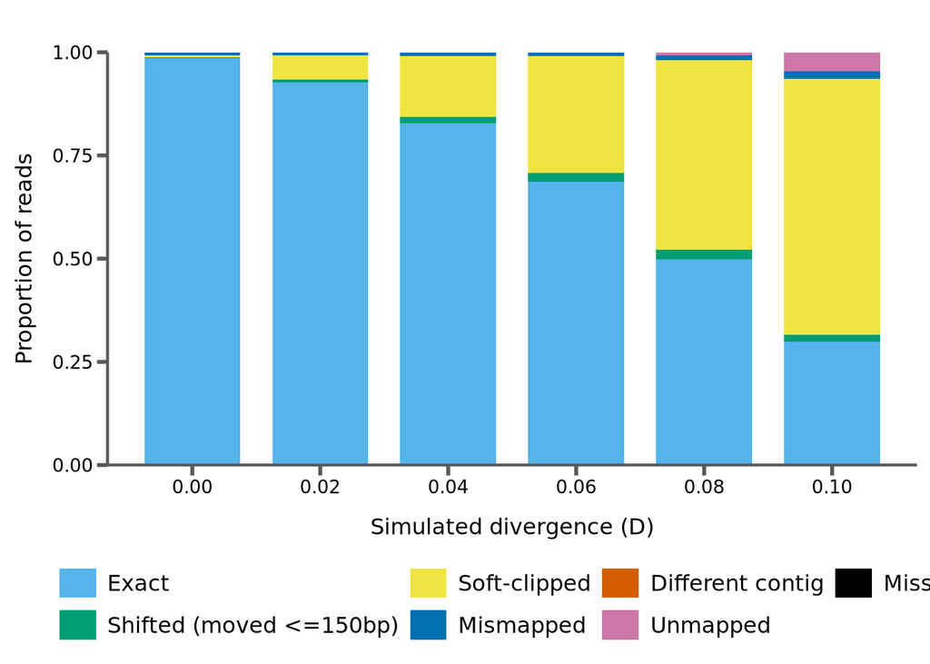

```r
read_classes <- c("exact","shifted","clipped","mismapped","diff_chr","unmapped","missing")
read_labels  <- c("Exact","Shifted (moved <=150bp)","Soft-clipped","Mismapped",
                  "Different contig","Unmapped","Missing")

read_long <- bam %>%
  select(divergence, all_of(paste0(read_classes, "_prop"))) %>%
  pivot_longer(-divergence, names_to = "class", values_to = "prop") %>%
  mutate(class = factor(sub("_prop","",class), levels = read_classes))

cols <- corecol(pal = "wilke", numcol = length(read_classes), offset = 1)

ggplot(read_long, aes(x = divergence, y = prop, fill = class)) +
  geom_col(position = position_fill(reverse = TRUE), width = 0.015) +
  scale_x_continuous(breaks = unique(read_long$divergence)) +
  scale_y_continuous(expand = c(0,0)) +
  scale_fill_manual(values = cols, labels = read_labels) +
  xlab("Simulated divergence (D)") + ylab("Proportion of reads") +
  bartheme() + theme(legend.position = "bottom")
```

## 2.2 Non-exact placements: clipping dominates

Isolating the non-exact classes shows the mechanism clearly: **soft-clipping grows explosively with divergence** (0.6% → 62% of reads at D=0.10), while a whole-read positional **shift stays negligible** (~2%). Mismapping rises only gently, `unmapped` dropout appears only at 8–10%, and **`missing` is exactly zero** throughout (the v1 liftover artifact is gone).

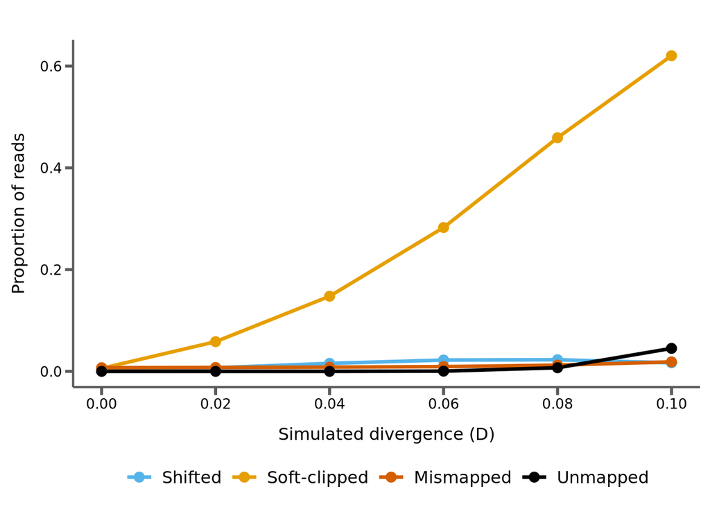

```r
err_long <- read_long %>% filter(class %in% c("shifted","clipped","mismapped","unmapped"))
ecols <- c("shifted"="#56b4e9","clipped"="#e69f00","mismapped"="#d55e00","unmapped"="#000000")

ggplot(err_long, aes(x = divergence, y = prop, color = class)) +
  geom_line(size = 1.2) + geom_point(size = 3) +
  scale_x_continuous(breaks = unique(err_long$divergence)) +
  scale_color_manual(values = ecols,
                     labels = c("Shifted","Soft-clipped","Mismapped","Unmapped")) +
  xlab("Simulated divergence (D)") + ylab("Proportion of reads") +
  bartheme() + theme(legend.position = "bottom")
```

**Interpretation.** Reads almost always land at the right locus (mismapping stays <2%, and true `unmapped` dropout appears only at the highest divergence). What changes overwhelmingly is **soft-clipping**: by D=0.10 nearly two-thirds of reads have a divergent end clipped off. The clipped bases are exactly the ones carrying alternate alleles, so clipping removes alt evidence near read ends — but, as the mechanism and caller sections below show, `bwa`+GATK still recover most sites, and the dominant loss is downstream in the caller, not here in placement.

# 3 Reference bias in variant calling

## 3.1 Fate of true divergence sites

Every truth divergence site is homozygous-alternate and *should* be called homozygous-alt. The stacked bars show what actually happens. The growing dark band is `div_ref_or_absent` — sites where the divergent allele is lost and the sample looks like the reference.

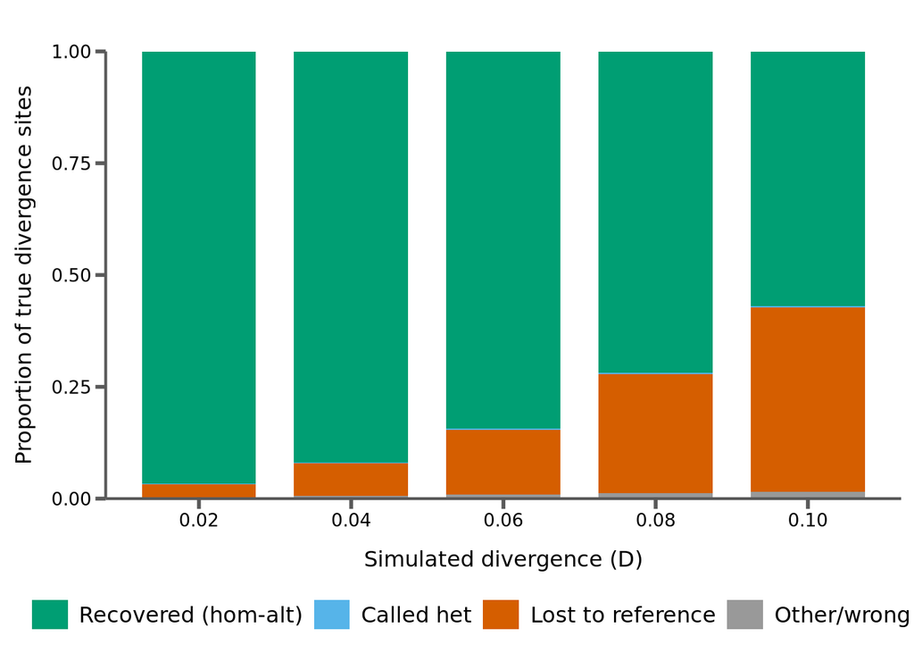

```r
div_classes <- c("div_tp","div_het","div_ref_or_absent","div_other")
div_labels  <- c("Recovered (hom-alt)","Called het",
                 "Lost to reference","Other/wrong allele")

div_long <- vcf %>%
  filter(divergence > 0) %>%                       # no divergence sites at D=0
  select(divergence, n_truth_div, all_of(div_classes)) %>%
  pivot_longer(all_of(div_classes), names_to = "class", values_to = "n") %>%
  mutate(prop = n / n_truth_div,
         class = factor(class, levels = rev(div_classes)))

dcols <- c("div_tp"="#009e73","div_het"="#56b4e9",
           "div_ref_or_absent"="#d55e00","div_other"="#999999")

ggplot(div_long, aes(x = divergence, y = prop, fill = class)) +
  geom_col(position = position_fill(reverse = TRUE), width = 0.015) +
  scale_x_continuous(breaks = unique(div_long$divergence)) +
  scale_y_continuous(expand = c(0,0)) +
  scale_fill_manual(values = dcols,
                    breaks = div_classes, labels = div_labels) +
  xlab("Simulated divergence (D)") + ylab("Proportion of true divergence sites") +
  bartheme() + theme(legend.position = "bottom")
```

## 3.2 The headline: divergence lost to the reference

This is the core reference-bias measurement — the fraction of true fixed differences that are called as reference (or not called at all) — plotted against divergence.

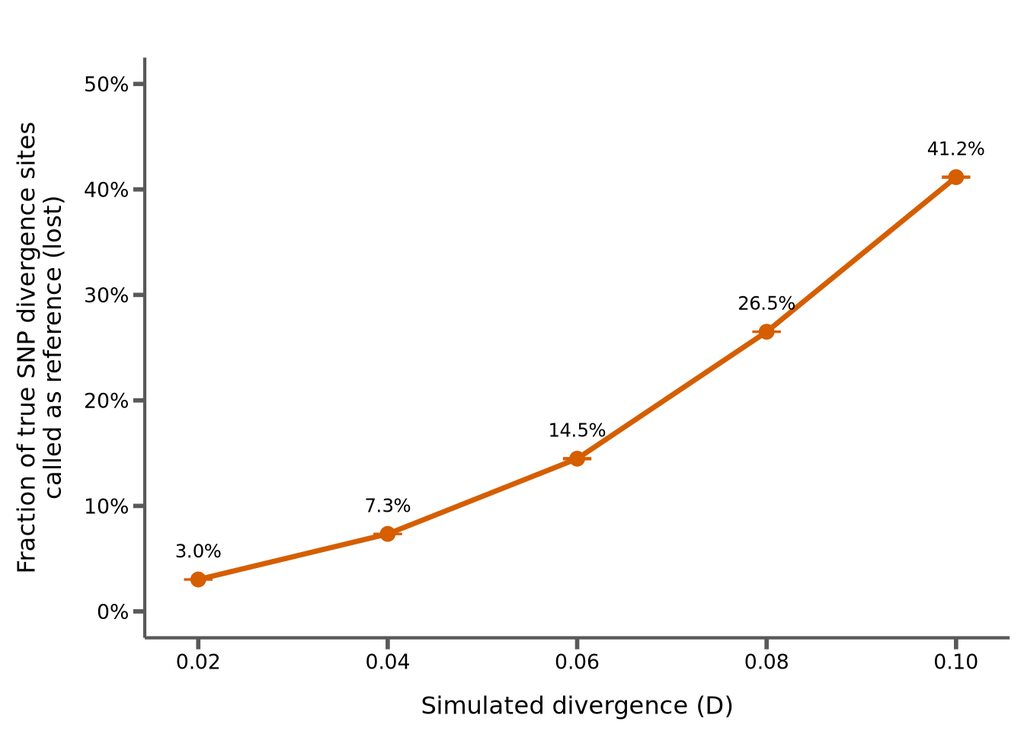

```r
bias <- vcf_raw %>%
  filter(divergence > 0) %>%
  mutate(lost_rate = div_ref_or_absent / n_truth_div) %>%
  group_by(divergence) %>%
  summarize(mean = mean(lost_rate), sd = sd(lost_rate), .groups = "drop")

col5 <- corecol(pal="wilke", numcol=1, offset=5)
ggplot(bias, aes(x = divergence, y = mean)) +
  geom_line(size = 1.2, color = col5) +
  geom_errorbar(aes(ymin = mean - sd, ymax = mean + sd), width = 0.003, color = col5) +
  geom_point(size = 3, color = col5) +
  geom_text(aes(label = scales::percent(mean, accuracy = 0.1)), vjust = -1.6, size = 3.2) +
  scale_x_continuous(breaks = bias$divergence) +
  scale_y_continuous(labels = scales::percent, limits = c(0, 0.5)) +
  xlab("Simulated divergence (D)") +
  ylab("Fraction of true SNP divergence sites\ncalled as reference (lost)") +
  bartheme()
```

**Interpretation.** Reference bias in SNP calling scales steeply and super-linearly with divergence: ~3% of fixed differences are lost at 2% divergence, rising to **~41% at 10% divergence** (error bars are tiny — the three seeds agree closely). At those sites the diverged sample is genotyped as identical to the reference — the empirical phenomenon these simulations were built to quantify, now measured against clean truth. Note this is *higher* than an equivalent SNP-only genome (~30% at D=0.10): the indels the sample also carries degrade nearby SNP recovery, so ignoring indels would **understate** reference bias.

# 4 Heterozygosity recovery

Heterozygosity is held constant at 0.5% across the sweep, yet recovery of het sites degrades as the surrounding divergence increases: het sites embedded in more-divergent sequence increasingly drop out (called reference), so heterozygosity is progressively **underestimated** the more the sample differs from the reference.

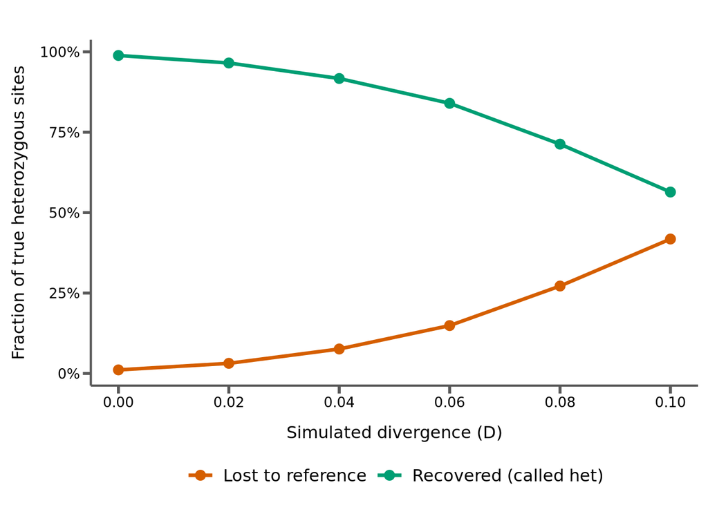

```r
het <- vcf %>%
  mutate(het_tp_rate = het_tp / n_truth_het,
         het_lost_rate = het_ref_or_absent / n_truth_het)

ggplot(het, aes(x = divergence)) +
  geom_line(aes(y = het_tp_rate, color = "Recovered (called het)"), size = 1.2) +
  geom_point(aes(y = het_tp_rate, color = "Recovered (called het)"), size = 3) +
  geom_line(aes(y = het_lost_rate, color = "Lost to reference"), size = 1.2) +
  geom_point(aes(y = het_lost_rate, color = "Lost to reference"), size = 3) +
  scale_x_continuous(breaks = het$divergence) +
  scale_y_continuous(labels = scales::percent) +
  scale_color_manual(values = c("Recovered (called het)" = "#009e73",
                                "Lost to reference" = "#d55e00")) +
  xlab("Simulated divergence (D)") +
  ylab("Fraction of true heterozygous sites") +
  bartheme() + theme(legend.position = "bottom")
```

# 5 Reference bias: SNPs vs. indels

Because the sample genome carries both SNPs and small indels, we can ask directly whether indels suffer *more* reference bias than SNPs — the mechanistic expectation (a read carrying a non-reference indel must be placed with a gap, which aligners penalize far more heavily than a mismatch). Both curves are the fraction of fixed (homozygous) differences that were called as reference, averaged over the three seeds.

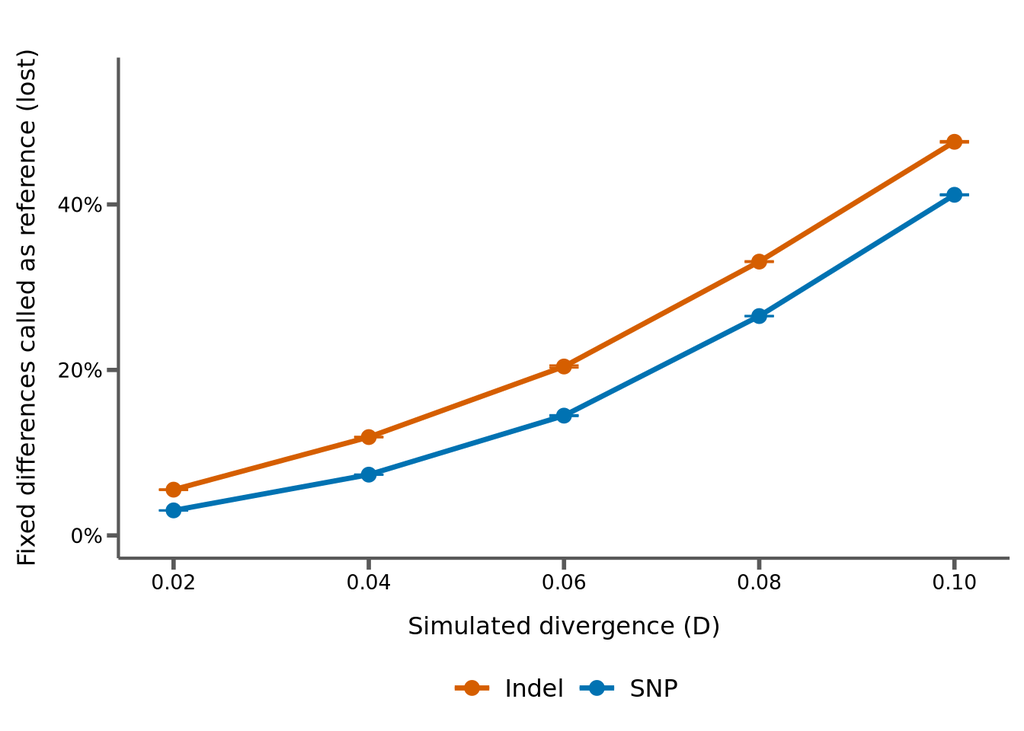

```r
lost_by_type <- vcf_raw %>%
  filter(divergence > 0) %>%
  mutate(SNP   = div_ref_or_absent / n_truth_div,
         Indel = indel_div_ref_or_absent / n_truth_indel_div) %>%
  select(divergence, seed, SNP, Indel) %>%
  pivot_longer(c(SNP, Indel), names_to = "type", values_to = "lost") %>%
  group_by(divergence, type) %>%
  summarize(mean = mean(lost), sd = sd(lost), .groups = "drop")

ggplot(lost_by_type, aes(x = divergence, y = mean, color = type)) +
  geom_line(size = 1.2) +
  geom_errorbar(aes(ymin = mean - sd, ymax = mean + sd), width = 0.003) +
  geom_point(size = 3) +
  scale_x_continuous(breaks = unique(lost_by_type$divergence)) +
  scale_y_continuous(labels = scales::percent, limits = c(0, 0.55)) +
  scale_color_manual(values = c("SNP" = "#0072b2", "Indel" = "#d55e00")) +
  xlab("Simulated divergence (D)") +
  ylab("Fixed differences called as reference (lost)") +
  bartheme() + theme(legend.position = "bottom")
```

**Interpretation.** Indels are lost to the reference at a **higher rate than SNPs at every divergence level** — from ~1.8× worse at low divergence (5.5% vs 3.0% at D=0.02) to ~1.15× worse at high divergence (47.6% vs 41.2% at D=0.10). This confirms, in our own controlled measurement, the expectation that reference bias is stronger around indels; the gap is proportionally largest when divergence is low, exactly where a single indel stands out most against otherwise reference-matching sequence.

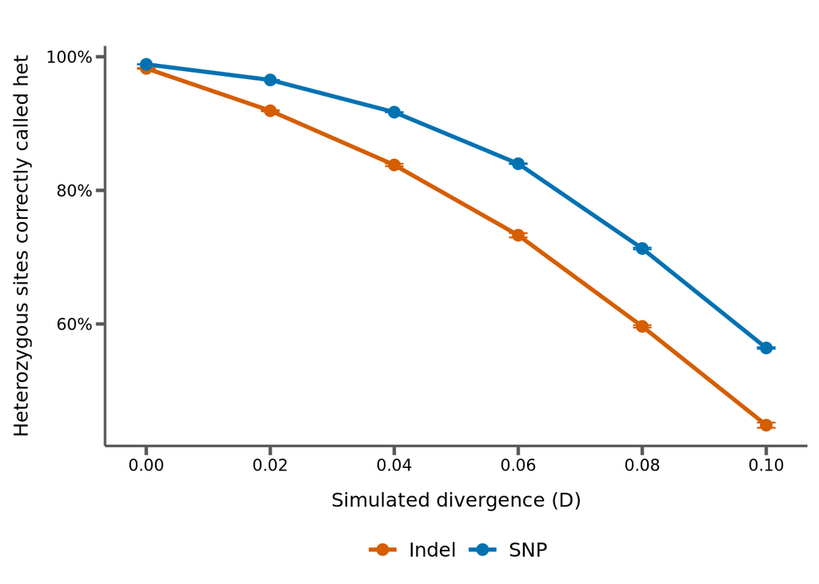

```r
het_by_type <- vcf_raw %>%
  mutate(SNP   = het_tp / n_truth_het,
         Indel = indel_het_tp / n_truth_indel_het) %>%
  select(divergence, seed, SNP, Indel) %>%
  pivot_longer(c(SNP, Indel), names_to = "type", values_to = "rec") %>%
  group_by(divergence, type) %>%
  summarize(mean = mean(rec), sd = sd(rec), .groups = "drop")

ggplot(het_by_type, aes(x = divergence, y = mean, color = type)) +
  geom_line(size = 1.2) +
  geom_errorbar(aes(ymin = mean - sd, ymax = mean + sd), width = 0.003) +
  geom_point(size = 3) +
  scale_x_continuous(breaks = unique(het_by_type$divergence)) +
  scale_y_continuous(labels = scales::percent) +
  scale_color_manual(values = c("SNP" = "#0072b2", "Indel" = "#d55e00")) +
  xlab("Simulated divergence (D)") +
  ylab("Heterozygous sites correctly called het") +
  bartheme() + theme(legend.position = "bottom")
```

**Interpretation.** Heterozygous indels are also recovered less well than heterozygous SNPs across the whole range (e.g. 45% vs 56% at D=0.10), so the underestimation of within-sample variation under reference bias is worse for indels than for SNPs.

# 6 False positives

False positives (positions called variant that are not truth sites) remain a small fraction of calls, but rise with divergence — a secondary effect of mismapped, allele-mismatched reads accumulating in more-divergent simulations.

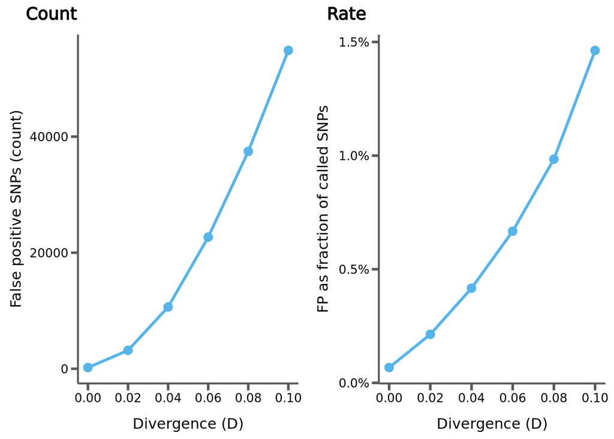

```r
fp <- vcf %>% mutate(fp_rate = fp / n_called_snp)

p_fp_n <- ggplot(fp, aes(x = divergence, y = fp)) +
  geom_line(size = 1.1, color = corecol(pal="wilke", numcol=1, offset=1)) +
  geom_point(size = 3, color = corecol(pal="wilke", numcol=1, offset=1)) +
  scale_x_continuous(breaks = fp$divergence) +
  xlab("Divergence (D)") + ylab("False positive SNPs (count)") + bartheme()

p_fp_r <- ggplot(fp, aes(x = divergence, y = fp_rate)) +
  geom_line(size = 1.1, color = corecol(pal="wilke", numcol=1, offset=1)) +
  geom_point(size = 3, color = corecol(pal="wilke", numcol=1, offset=1)) +
  scale_x_continuous(breaks = fp$divergence) +
  scale_y_continuous(labels = scales::percent) +
  xlab("Divergence (D)") + ylab("FP as fraction of called SNPs") + bartheme()

plot_grid(p_fp_n, p_fp_r, ncol = 2, labels = c("Count","Rate"))
```

# 7 Mechanism: why are divergence sites lost?

*Data note: this section uses the earlier SNP-only replicate (seed 42), which is why its SNP loss rates run slightly lower than the SNP+indel results above. The mechanism it isolates — the shift from mapping-limited to caller-limited loss with divergence — is the point here and is unaffected.*

The variant-calling section shows divergence sites increasingly called as reference, but not *why*. To pin down the mechanism without the divergence confound, we take a **per-site** view at each divergence level: every truth divergence site is homozygous-alternate, so every read that *truly* covers it (known exactly from the mason truth BAM) should carry the ALT allele. We trace each such read to its fate in the mapped BAM and compare **recovered** sites (`div_tp`) against **lost** sites (`div_ref_or_absent`) at the *same* divergence.

**Sampling / definitions.** Up to 10,000 sites per outcome class per divergence were randomly sampled (seed 42); D=0.00 has no divergence sites and is omitted. A read’s fate is *retained* (aligned across the site, showing ALT / REF / other base), *soft-clipped over the site*, *mismapped* (>150 bp from truth), or *unmapped*. The “effective ALT fraction” counts only MAPQ ≥ 20 reads — the reads GATK HaplotypeCaller actually uses — so sites lost to low mapping quality are separated from sites lost to read dropout. See `summary-data/mm39-mason-chr19-site-linkage.csv.dict.txt` for full field definitions.

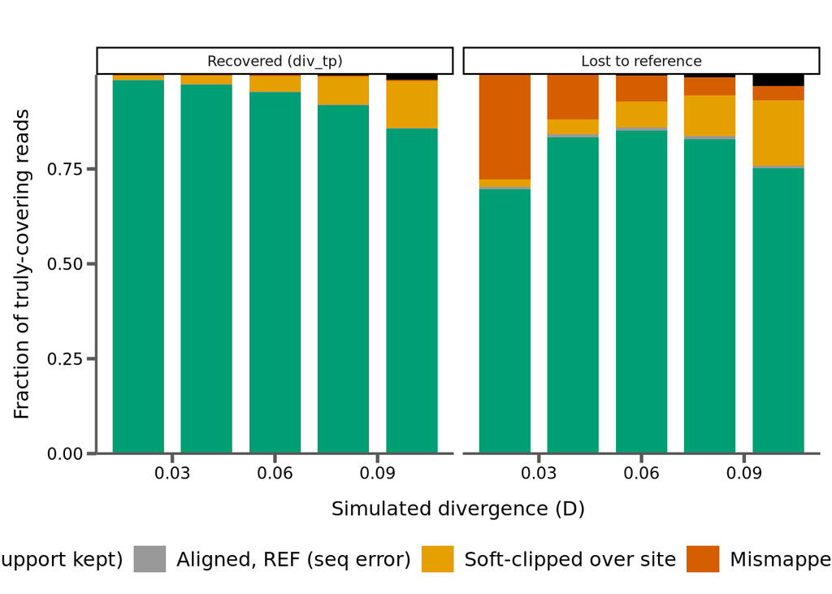

```r
link <- read_csv("summary-data/mm39-mason-chr19-site-linkage.csv")

fate_cols <- c("retained_alt","retained_ref","clipped","mismapped","unmapped")
fate_labs <- c("Aligned, ALT (support kept)","Aligned, REF (seq error)",
               "Soft-clipped over site","Mismapped (>150bp)","Unmapped")

# Fraction of truly-covering reads in each fate, weighted by site depth,
# split by call outcome and divergence.
fate_summ <- link %>%
  group_by(divergence, outcome) %>%
  summarize(truth = sum(truth_depth),
            across(all_of(fate_cols), sum), .groups = "drop") %>%
  mutate(across(all_of(fate_cols), ~ .x / truth)) %>%
  pivot_longer(all_of(fate_cols), names_to = "fate", values_to = "frac") %>%
  mutate(fate = factor(fate, levels = fate_cols),
         outcome = factor(outcome, levels = c("tp","lost"),
                          labels = c("Recovered (div_tp)","Lost to reference")))

fcols <- c("retained_alt"="#009e73","retained_ref"="#999999",
           "clipped"="#e69f00","mismapped"="#d55e00","unmapped"="#000000")

ggplot(fate_summ, aes(x = divergence, y = frac, fill = fate)) +
  geom_col(position = position_stack(reverse = TRUE), width = 0.015) +
  facet_wrap(~outcome) +
  scale_fill_manual(values = fcols, breaks = fate_cols, labels = fate_labs) +
  scale_y_continuous(expand = c(0,0)) +
  xlab("Simulated divergence (D)") + ylab("Fraction of truly-covering reads") +
  bartheme() + theme(legend.position = "bottom")
```

**Interpretation.** Recovered sites keep almost all reads aligned with ALT support at every divergence. Lost sites lose reads by two different routes: **mismapping** dominates at low divergence (repetitive regions), while **soft-clipping over the site** grows with divergence. But note both effects are partial — even lost sites keep most of their alt-bearing reads.

## 7.1 Effective alternate-allele fraction the caller sees

If read dropout were the whole story, lost sites would show a depressed ALT fraction. This plots the effective ALT fraction (MAPQ ≥ 20 reads) for recovered vs. lost sites.

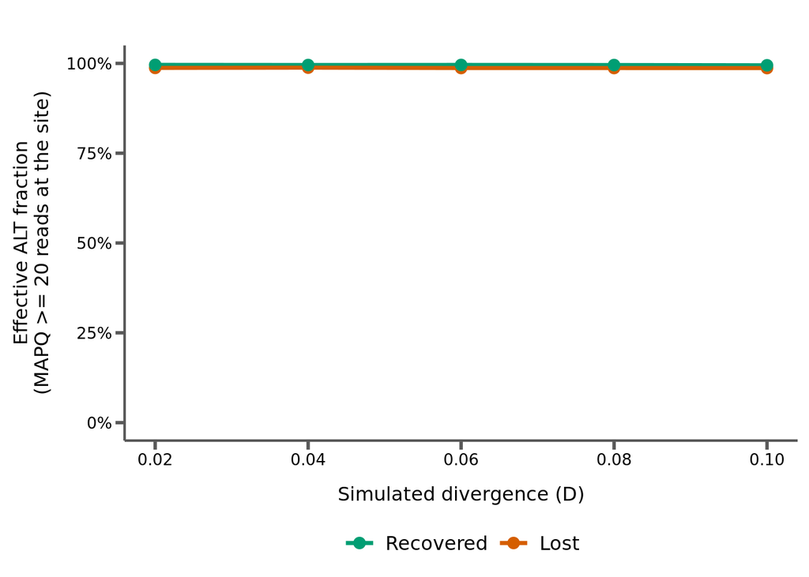

```r
vaf <- link %>%
  group_by(divergence, outcome) %>%
  summarize(alt_hq = sum(pileup_alt_hq), depth_hq = sum(pileup_depth_hq),
            .groups = "drop") %>%
  mutate(alt_frac_hq = alt_hq / depth_hq,
         outcome = factor(outcome, levels = c("tp","lost"),
                          labels = c("Recovered","Lost")))

ggplot(vaf, aes(x = divergence, y = alt_frac_hq, color = outcome)) +
  geom_line(size = 1.2) + geom_point(size = 3) +
  scale_color_manual(values = c("Recovered"="#009e73","Lost"="#d55e00")) +
  scale_y_continuous(labels = scales::percent, limits = c(0,1)) +
  xlab("Simulated divergence (D)") +
  ylab("Effective ALT fraction\n(MAPQ >= 20 reads at the site)") +
  bartheme() + theme(legend.position = "bottom")
```

## 7.2 Two mechanisms, shifting with divergence

Classifying each lost site by whether its alternate evidence was actually degraded (effective ALT fraction < 50%, a read-mapping failure) or was present but uncalled (≥ 50%, a caller/region-complexity failure) shows the balance tip with divergence.

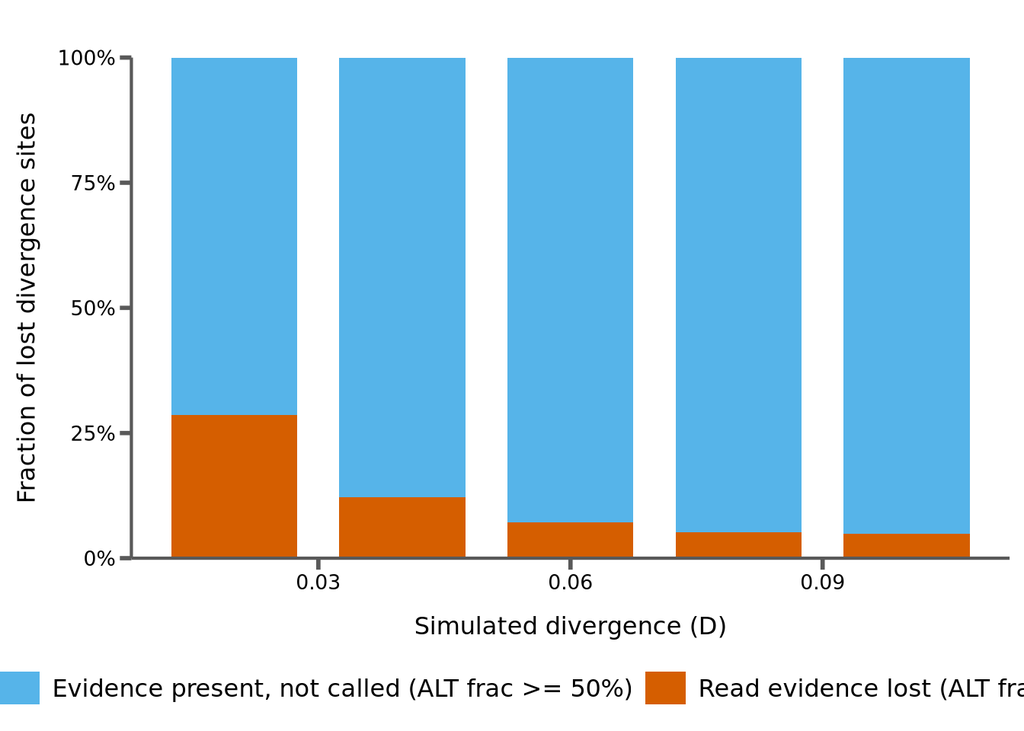

```r
VAF_CUT <- 0.5   # heuristic: a hom-alt site with >=50% MAPQ>=20 ALT should be callable
cause <- link %>%
  filter(outcome == "lost") %>%
  mutate(cause = ifelse(pileup_alt_frac_hq < VAF_CUT,
                        "Read evidence lost (ALT frac < 50%)",
                        "Evidence present, not called (ALT frac >= 50%)")) %>%
  group_by(divergence, cause) %>%
  summarize(n = n(), .groups = "drop") %>%
  group_by(divergence) %>%
  mutate(frac = n / sum(n))

ccols <- c("Read evidence lost (ALT frac < 50%)"="#d55e00",
           "Evidence present, not called (ALT frac >= 50%)"="#56b4e9")

ggplot(cause, aes(x = divergence, y = frac, fill = cause)) +
  geom_col(width = 0.015) +
  scale_fill_manual(values = ccols) +
  scale_y_continuous(labels = scales::percent, expand = c(0,0)) +
  xlab("Simulated divergence (D)") +
  ylab("Fraction of lost divergence sites") +
  bartheme() + theme(legend.position = "bottom")
```

**Interpretation & takeaway.** Reference bias in the *calls* has two mechanisms whose balance shifts with divergence:

- **Low divergence — mapping-limited.** Lost sites are concentrated in repetitive regions where alt-bearing reads mismap, depressing the alternate fraction below the callable range.
- **High divergence — caller-limited.** Reads still carry the alternate allele with high MAPQ, yet the sites are lost. This is *not* mainly about soft-clipping (which rises with divergence but affects recovered sites too) — it is a property of GATK HaplotypeCaller’s local reassembly step (see the caller-swap test below).

## 7.3 What the losses actually are: density vs. caller

Two direct checks pin this down.

*Local variant density* only **weakly** distinguishes lost from recovered sites: the median distance to the nearest other variant is just 1–2 bp smaller at lost sites (e.g. 3 vs 4 bp at D=0.10), and at high divergence ~99% of *all* sites have a neighbour within 20 bp. So “dense region” is not a clean explanation — an earlier draft overstated it.

*Swapping the caller* is decisive. Re-calling the D=0.10 BAM with a **pileup-based** caller (`bcftools`, which does no local reassembly) recovers the GATK-lost sites by outcome class:

| GATK site class | bcftools recovers |
| --- | --- |
| recovered by GATK (sanity check) | 99.2% |
| GATK-lost, evidence *degraded* (ALT frac < 50%) | 0.6% |
| GATK-lost, evidence *present* (ALT frac ≥ 50%) | **98.7%** |

So the large “evidence present but uncalled” class is **~99% recoverable simply by using a non-assembly caller** — the loss is specific to HaplotypeCaller’s assembly, not a lack of evidence. The “evidence degraded” (mapping-limited) sites are recovered by neither caller, as expected — those need better *mapping*, not a better caller.

*Caveats: the caller-swap is one condition (D=0.10, one seed) and measures **recall only** — bcftools’ false-positive rate at high divergence has not yet been checked, so “more robust” is provisional pending a precision comparison. The 50% ALT-fraction cutoff separating the two lost classes is a heuristic.*

## 7.4 Decomposition: which mechanism drives the loss?

Putting it together — the overall SNP loss rate split into its two mechanisms as a fraction of *all* true divergence sites. Each cell is how much of the genome’s fixed SNP differences are lost to that mechanism at that divergence.

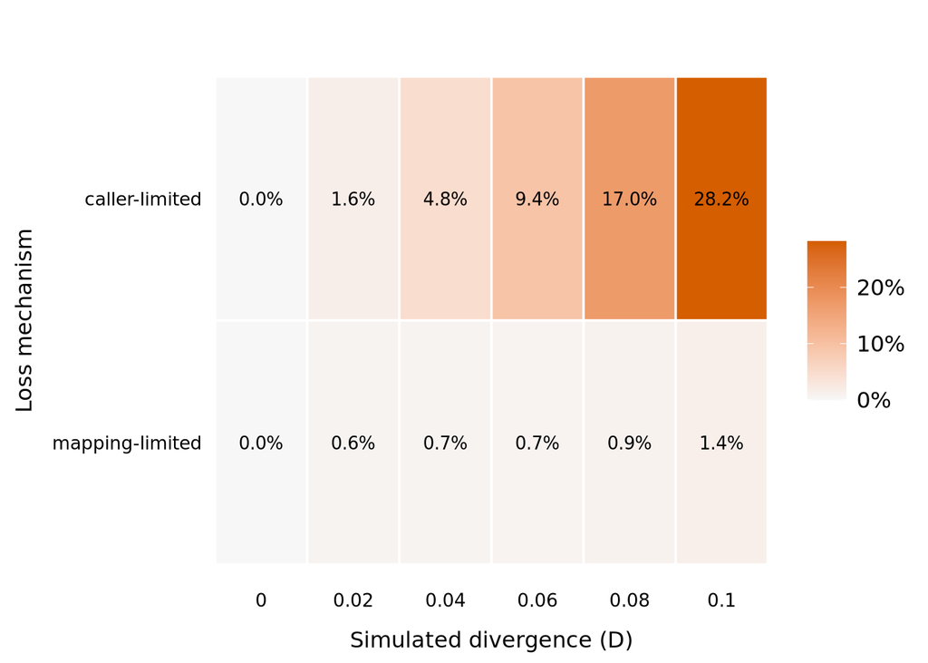

```r
decomp <- read_csv("summary-data/mm39-mason-chr19-loss-decomposition.csv") %>%
  mutate(mechanism = factor(mechanism, levels = c("mapping-limited", "caller-limited")))

ggplot(decomp, aes(x = factor(divergence), y = mechanism, fill = frac_of_truth_lost)) +
  geom_tile(color = "white", size = 0.6) +
  geom_text(aes(label = scales::percent(frac_of_truth_lost, accuracy = 0.1)), size = 3.4) +
  scale_fill_gradient(low = "#f7f7f7", high = "#d55e00",
                      labels = scales::percent,
                      name = "Fraction of true\nSNP sites lost") +
  xlab("Simulated divergence (D)") + ylab("Loss mechanism") +
  bartheme() +
  theme(legend.position = "right", axis.line = element_blank(),
        axis.ticks = element_blank())
```

**Interpretation.** The two mechanisms behave completely differently. **Mapping-limited loss is a small, nearly flat floor** (~0.6% → 1.4% across the whole divergence range) — essentially the fixed repetitive fraction of the chromosome, where alt reads mismap no matter what. **Caller-limited loss explodes** (1.6% → 28%) and accounts for almost all of the growth in reference bias. So as divergence rises, the reference-bias problem is overwhelmingly the *assembly-based caller* failing on sites whose evidence is present — which is why it also resolves the earlier puzzle: mapping-limited loss barely changes in absolute terms, so its *share* of all lost sites shrinks even as more reads mismap. It also says where effort pays off: at realistic divergences, a better/pileup caller (or iterative mapping that lowers effective divergence) addresses the dominant term, while graph/iterative mapping chips at the small mapping-limited floor.

# 8 Variant caller benchmark

The mechanism section showed the high-divergence SNP loss is specific to GATK HaplotypeCaller’s assembly. Here we test that comprehensively: **holding mapping fixed** (the same bwa BAMs), we call variants with three callers spanning the strategy axis — **gatk** (reference-anchored De Bruijn assembly), **bcftools** (pileup, no assembly), and **freebayes** (haplotype-from-alignment, no k-mer reassembly) — and score each caller’s **recall and precision** across the divergence sweep. All callers use their native output normalized identically (`bcftools norm -m- --atomize`), so precision reflects each caller’s intrinsic false-positive tradeoff.

```r
cb <- read_csv("summary-data/mm39-mason-chr19-caller-benchmark.csv") %>%
  mutate(caller = factor(caller, levels = c("gatk", "bcftools", "freebayes")))

cb_m <- cb %>% group_by(caller, divergence) %>%
  summarize(snp_recall    = mean(div_tp / n_truth_div),
            snp_precision  = mean(1 - fp / n_called_snp),
            indel_recall   = mean(indel_div_tp / n_truth_indel_div),
            .groups = "drop")

# heatmap helper: caller (y) x divergence (x), fill = metric
caller_heatmap <- function(df, metric, name, high) {
  ggplot(df, aes(x = factor(divergence), y = caller, fill = .data[[metric]])) +
    geom_tile(color = "white", size = 0.6) +
    geom_text(aes(label = scales::percent(.data[[metric]], accuracy = 1)), size = 3.2) +
    scale_fill_gradient(low = "#f7f7f7", high = high, labels = scales::percent,
                        limits = c(0, 1), name = name) +
    xlab("Divergence (D)") + ylab(NULL) + bartheme() +
    theme(axis.line = element_blank(), axis.ticks = element_blank(),
          legend.position = "right")
}
```

## 8.1 SNP recall and precision

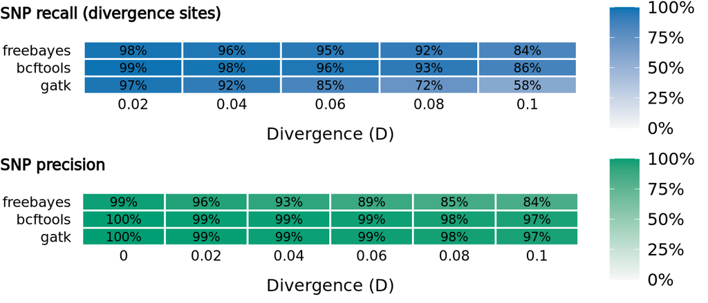

```r
r <- caller_heatmap(filter(cb_m, divergence > 0), "snp_recall", "SNP\nrecall", "#0072b2")
p <- caller_heatmap(cb_m, "snp_precision", "SNP\nprecision", "#009e73")
cowplot::plot_grid(r, p, ncol = 1, labels = c("SNP recall (divergence sites)", "SNP precision"),
                   label_size = 11, hjust = 0)
```

**Interpretation.** For SNPs, **both non-assembly callers dramatically out-recall GATK** as divergence rises — at D=0.10, GATK recovers only 58% of fixed SNP differences vs 86% (bcftools) and 84% (freebayes). But the precision panel shows the catch: **bcftools keeps GATK-level precision (~97%)**, while **freebayes’ precision collapses to ~84%** (one in six of its calls is a false positive at D=0.10). So for SNPs at high divergence, **bcftools is the clear win** — large recall gain at essentially no precision cost — whereas freebayes buys recall with a heavy false-positive penalty.

## 8.2 Indels — the tradeoff reverses

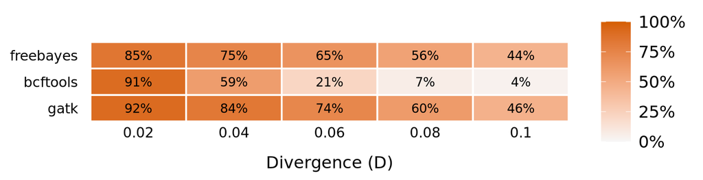

```r
caller_heatmap(filter(cb_m, divergence > 0), "indel_recall", "Indel\nrecall", "#d55e00")
```

**Interpretation.** For indels the ranking flips: **bcftools collapses** (indel recall falls to ~4% at D=0.10), while GATK and freebayes retain ~45%. Pileup calling is intrinsically weak at indels — and worse in divergent, complex regions — whereas the assembly (GATK) and haplotype-from-alignment (freebayes) strategies reconstruct indels far better. So the very assembly/haplotype machinery that *hurts* GATK on divergent SNPs is what indels *need*.

## 8.3 Recall and precision vs divergence

Divergence on the x-axis, one line per caller, split into recall vs precision (rows) and SNP vs indel (columns). This is the at-a-glance view: read each panel left-to-right to see how that metric holds up (or doesn’t) as the sample diverges from the reference.

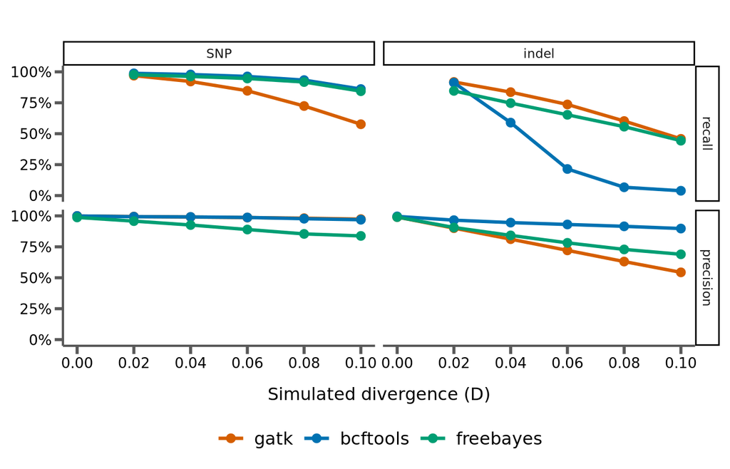

```r
metrics_long <- cb %>% group_by(caller, divergence) %>%
  summarize(`SNP recall`     = mean(div_tp / n_truth_div),
            `SNP precision`   = mean(1 - fp / n_called_snp),
            `indel recall`    = mean(indel_div_tp / n_truth_indel_div),
            `indel precision` = mean(ifelse(n_called_indel > 0, 1 - fp_indel / n_called_indel, NA)),
            .groups = "drop") %>%
  pivot_longer(-c(caller, divergence), names_to = "panel", values_to = "value") %>%
  separate(panel, into = c("variant", "metric"), sep = " ") %>%
  filter(!is.nan(value), !is.na(value))       # recall undefined at D=0

metrics_long$variant <- factor(metrics_long$variant, levels = c("SNP", "indel"))
metrics_long$metric  <- factor(metrics_long$metric,  levels = c("recall", "precision"))

ggplot(metrics_long, aes(x = divergence, y = value, color = caller)) +
  geom_line(size = 1.1) + geom_point(size = 2.5) +
  facet_grid(metric ~ variant) +
  scale_x_continuous(breaks = unique(metrics_long$divergence)) +
  scale_y_continuous(labels = scales::percent, limits = c(0, 1)) +
  scale_color_manual(values = c(gatk = "#d55e00", bcftools = "#0072b2", freebayes = "#009e73")) +
  labs(x = "Simulated divergence (D)", y = NULL) +
  bartheme() + theme(legend.position = "bottom")
```

## 8.4 Precision–recall trajectories (all methods in one view)

The same data as a precision–recall plot: each caller is a path through PR space, one point per divergence level, the arrow pointing toward *increasing* divergence. Top-right is the ideal (high recall and precision); a method that degrades gracefully stays near the top-right, one that trades recall or precision away slides left or down.

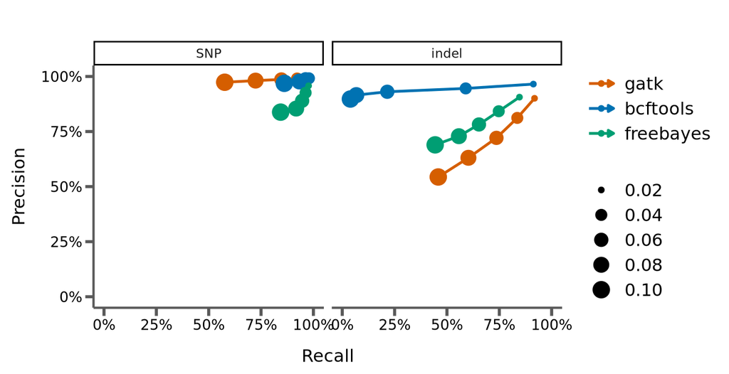

```r
pr <- cb %>% group_by(caller, divergence) %>%
  summarize(SNP_recall      = mean(div_tp / n_truth_div),
            SNP_precision    = mean(1 - fp / n_called_snp),
            indel_recall     = mean(indel_div_tp / n_truth_indel_div),
            indel_precision  = mean(ifelse(n_called_indel > 0, 1 - fp_indel / n_called_indel, NA)),
            .groups = "drop")

prl <- bind_rows(
  pr %>% transmute(caller, divergence, variant = "SNP",
                   recall = SNP_recall, precision = SNP_precision),
  pr %>% transmute(caller, divergence, variant = "indel",
                   recall = indel_recall, precision = indel_precision)
) %>% filter(divergence > 0) %>%           # recall undefined at D=0
  arrange(caller, variant, divergence)     # path order = increasing divergence

prl$variant <- factor(prl$variant, levels = c("SNP", "indel"))

ggplot(prl, aes(x = recall, y = precision, color = caller, group = caller)) +
  geom_path(arrow = arrow(length = unit(0.15, "cm"), type = "closed"), size = 0.9) +
  geom_point(aes(size = as.numeric(divergence))) +
  facet_wrap(~variant) +
  scale_x_continuous(labels = scales::percent, limits = c(0, 1)) +
  scale_y_continuous(labels = scales::percent, limits = c(0, 1)) +
  scale_color_manual(values = c(gatk = "#d55e00", bcftools = "#0072b2", freebayes = "#009e73")) +
  scale_size_continuous(name = "Divergence", range = c(1.5, 5)) +
  labs(x = "Recall", y = "Precision") +
  bartheme() + theme(legend.position = "right")
```

**Reading it.** *SNP panel:* bcftools (blue) stays pinned to the top-right — recall erodes only slightly and precision holds — while GATK (orange) slides straight left (recall collapses, precision intact) and freebayes (green) sags down-and-left (losing both). *Indel panel:* the picture inverts — GATK and freebayes stay upper/right-ish while bcftools shoots to the far left (indel recall → ~0). One figure captures the whole story: which method to trust depends on the variant type and how much precision vs recall you can spend.

This reframes “reference bias is a caller problem” precisely: it’s a caller problem *for SNPs*, fixable by dropping the assembly requirement — but indels genuinely need haplotype/assembly reconstruction, so the lever there is better *mapping* (graph or iterative, to lower effective divergence) rather than a simpler caller.

*Caveats: native (unfiltered) calls, so GATK’s numbers here differ from the filtered main-results section; chr19, single iteration, 3 seeds; freebayes’ complex alleles are atomized to compare fairly.*

# 9 Summary

*Scope: single chromosome (chr19), chr19-only mapping, 3 replicate seeds, single iteration. Whole-genome mapping, a v1-vs-v2 comparison, and iterative (pseudo-it) mapping are planned extensions.*